# Сеетевые технологии

## Построение туннеля IPv6–IPv4

[figure not shown]

Изменение имени устройства

## Построение туннеля IPv6–IPv4

[figure not shown]

Изменение имени устройства

## Построение туннеля IPv6–IPv4

Настроим адреса на интерфейсах маршрутизаторов.

msk-antoychubekova-gw-01.

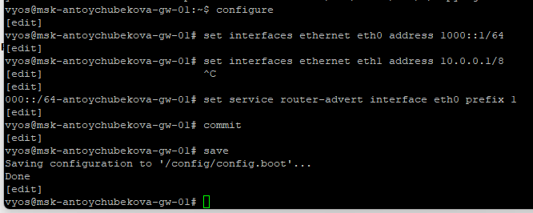

Настройка адресов

## Построение туннеля IPv6–IPv4

msk-antoychubekova-gw-02.

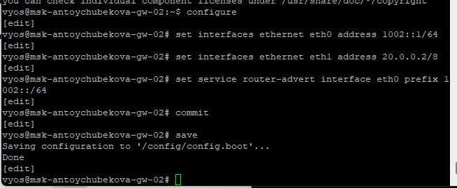

Настройка адресов

## Построение туннеля IPv6–IPv4

msk-antoychubekova-gw-03.

[figure not shown]

Настройка адресов

## Построение туннеля IPv6–IPv4

Убедимся, что на PC появились адреса ближайших к ним маршрутизаторов.

[figure not shown]

Адреса ближних маршрутизаторов

## Построение туннеля IPv6–IPv4

Проверим маршруты с маршрутизатора R1. Мы видим, что пингуется только первый адрес.

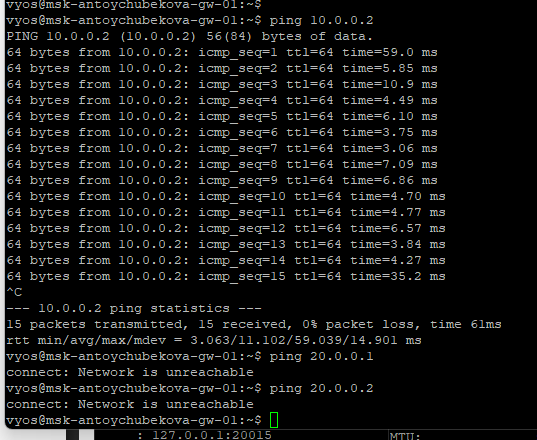

Маршруты с маршрутизатора R1

## Построение туннеля IPv6–IPv4

Просмотрим анализ трафика.

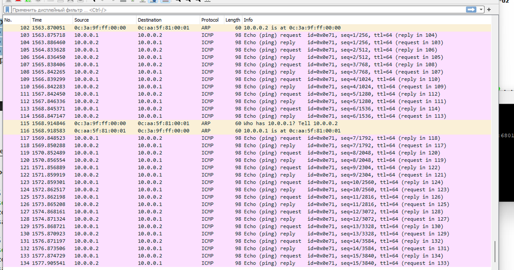

Анализ трафика

## Построение туннеля IPv6–IPv4

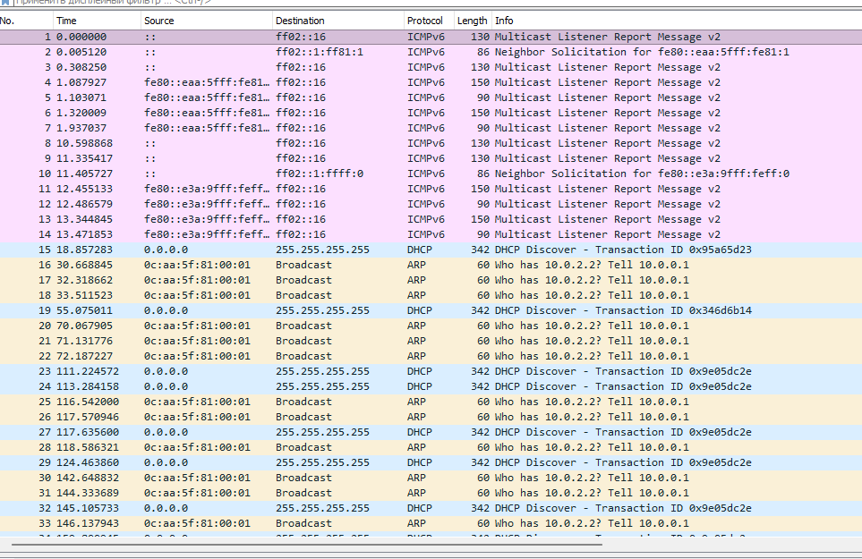

Анализ трафика

## Построение туннеля IPv6–IPv4

Настроим маршрутизацию IPv4.

msk-antoychubekova-gw-01.

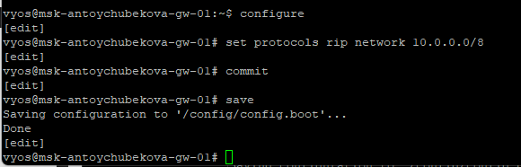

Настройка маршрутизации IPv4

## Построение туннеля IPv6–IPv4

msk-antoychubekova-gw-02.

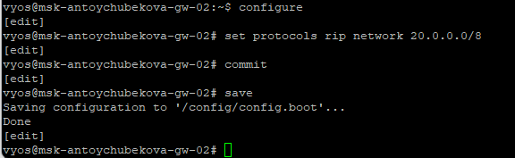

Настройка маршрутизации IPv4

## Построение туннеля IPv6–IPv4

msk-antoychubekova-gw-03.

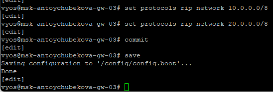

Настройка маршрутизации IPv4

## Построение туннеля IPv6–IPv4

Проверим маршруты. Мы видим, что все адреса пингуются.

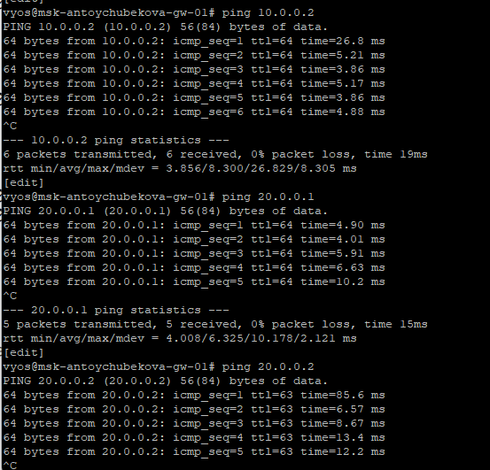

Проверка маршрута

## Построение туннеля IPv6–IPv4

Просмотрим анализ трафика.

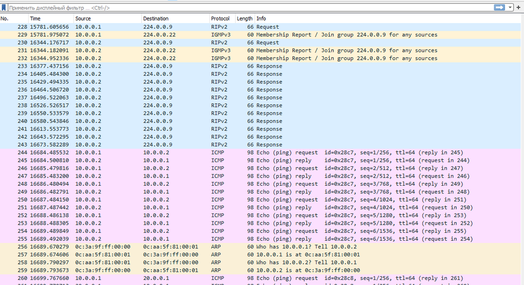

Анализ трафика

## Построение туннеля IPv6–IPv4

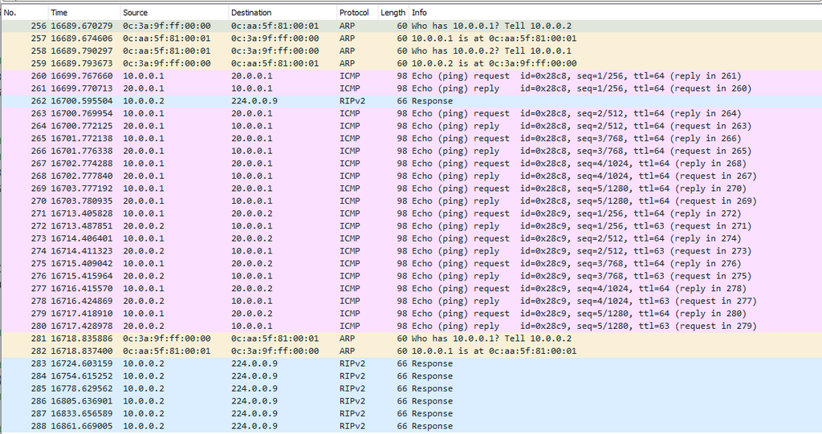

Анализ трафика

## Построение туннеля IPv6–IPv4

Создадим туннель IPv6 через сеть IPv4.

msk-antoychubekova-gw-01.

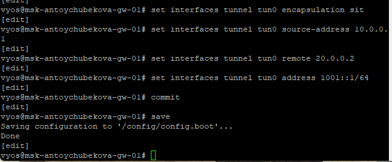

Создание туннеля IPv6 через сеть IPv4

## Построение туннеля IPv6–IPv4

msk-antoychubekova-gw-02.

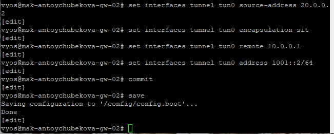

Создание туннеля IPv6 через сеть IPv4

## Построение туннеля IPv6–IPv4

Настроим статическую маршрутизацию IPv6.

msk-antoychubekova-gw-01.

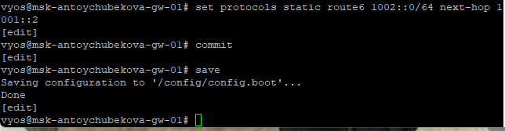

Настройка статичной маршрутизации IPv6

## Построение туннеля IPv6–IPv4

msk-antoychubekova-gw-02.

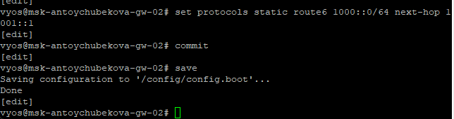

Настройка статичной маршрутизации IPv6

## Построение туннеля IPv6–IPv4

Проверим доступность оконечных устройств. Мы видим, что все корректно обрабатывается.

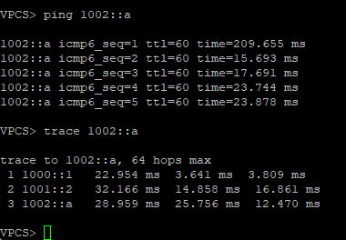

Отправка запроса c PC1 к РС2

## Построение туннеля IPv6–IPv4

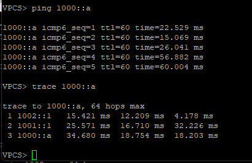

## Построение туннеля IPv6–IPv4

Просмотрим анализ трафика.

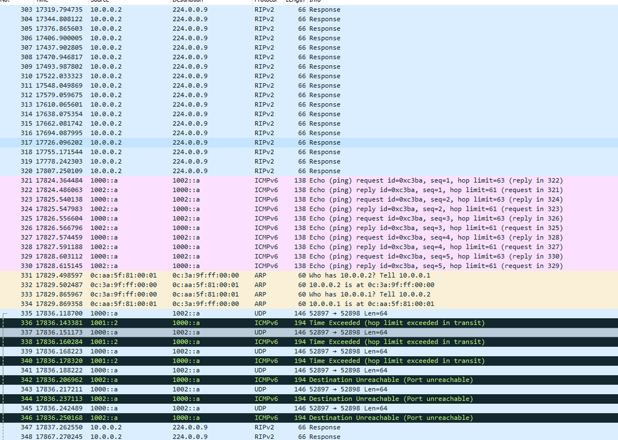

Анализ трафика

## Построение туннеля IPv6–IPv4

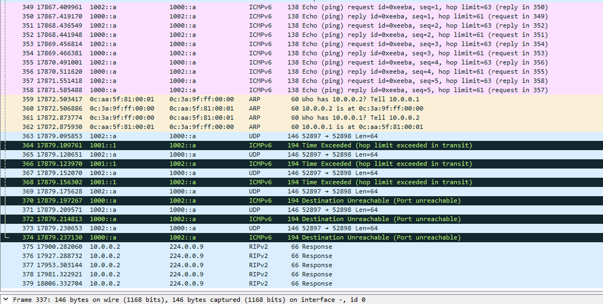

Анализ трафика

## Построение туннеля IPv6–IPv4

Пакеты, проходящие по туннелю, имеют одновременно поля IPv4 и IPv6.

[figure not shown]

Анализ трафика

## Построение туннеля IPv6–IPv4

[figure not shown]

Анализ трафика

## Задание для самостоятельного выполнения

У нас задана топология сети, адреса сегментов сети, адреса, назначаемые интерфейсам устройств

[figure not shown]

Топология сети

## Задание для самостоятельного выполнения

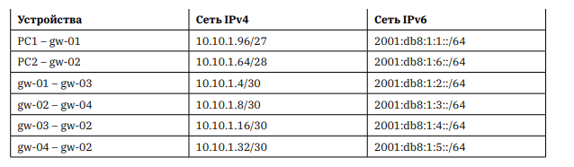

Адреса сегментов сети

## Задание для самостоятельного выполнения

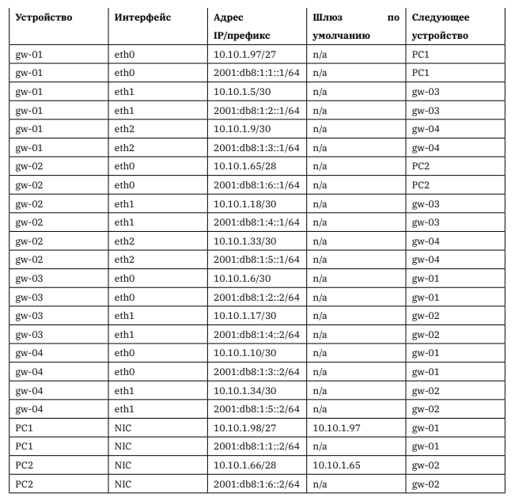

## Задание для самостоятельного выполнения

Присвоим IPv4 и IPv6-адресов оконечному устройству PC1 в соответствии с таблицей

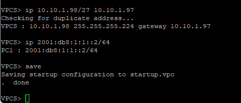

IPv4 и IPv6-адресов оконечному устройству PC1

## Задание для самостоятельного выполнения

Присвоим IPv4 и IPv6-адресов оконечному устройству PC2 в соответствии с таблицей

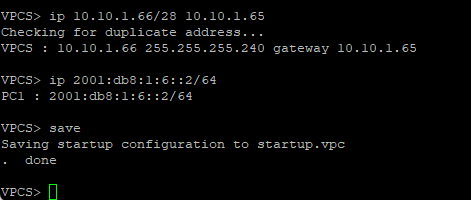

IPv4 и IPv6-адресов оконечному устройству PC2

## Задание для самостоятельного выполнения

Настроим IPv4-адреса на интерфейсах маршрутизатора msk-antoychubekova-gw-01.

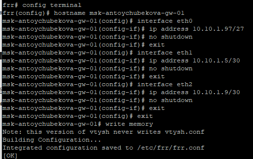

Настройка IPv4-адреса на msk-antoychubekova-gw-01

## Задание для самостоятельного выполнения

Настроим IPv4-адреса на интерфейсах маршрутизатора msk-antoychubekova-gw-02.

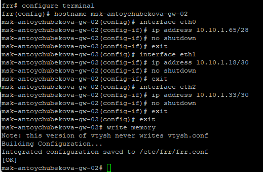

Настройка IPv4-адреса на msk-antoychubekova-gw-02